# AQI Analysis

Michael Polonio

2/16/2021

## Introduction

The main objective of this paper is to explore and visualize data gathered by United States Environmental Protection Agency. We will be looking at the differing levels of Air Quality Index (AQI) based on variables such as population density, percentage of poverty, and county area (sqMi). It’s important to note that the air quality decreases as the AQI increases (The lower the AQI is, the better the air quality).

## Methods

The expss package in R was used to conduct this analysis. In the dataset used, there were 41,501 observations taken from a region with with various levels of AQI, population density, and percentage living in poverty. The observation are classified by having an AQI of Good (0 - 51), Moderate (51 - 99), and Unhealthy for Sensitive Groups (100+).

### Baseline Statistics

We can see from Figure 1 that the mean of the AQI over the region is 31.2, mean of the percentage of poverty is 15.72, and mean of the population density (sqMi) is 1079.43. Figure 2 shows us a table of the levels of AQI through the range of poverty percentage.

```r
library(ggplot2);library(ggthemes);library(dplyr);library(magrittr);library(ggsci);library(expss)
df = apply_labels(df,
                  CountyPopDensity_perSqMile = "Population Density (SqMi)",
                  DateMsrmt = "Date of Measurement",
                  Category = "Category",
                  Category = c("Good" = 0,
                               "Moderate" = 1,
                               "Unhealthy for Sensitive Groups" = 2),
                  PercentPoverty = "Percentage of Poverty"
                  )

expss::expss_digits(digits = 2)
htmlTable(
  df %>% tab_cells(AQI, PercentPoverty,CountyPopDensity_perSqMile) %>%
    tab_stat_fun(Mean=w_mean,SD=w_sd,method=list ) %>%
    tab_pivot() %>%
    set_caption("Figure 1")
)
```

| Figure 1 | Figure 1 #Total Mean | Figure 1 #Total SD |
| --- | --- | --- |
| AQI | 31.20 | 17.63 |
| Percentage of Poverty | 15.72 | 7.20 |
| Population Density (SqMi) | 1079.43 | 4390.46 |

```r
cro(df$PercentPoverty, df$Category) %>% htmlTable() %>%
    set_caption("Figure 2")
```

Figure 2

|  | Category Good | Category Moderate | Category Unhealthy for Sensitive Groups | Category Good | Category Moderate | Category Unhealthy for Sensitive Groups |
| --- | --- | --- | --- | --- | --- | --- |
| Percentage of Poverty |  |  |  |  |  |  |
| 4 |  |  |  | 215 | 55 | 4 |
| 4.4 |  |  |  | 504 | 42 |  |
| 5.3 |  |  |  | 514 | 28 |  |
| 5.4 |  |  |  | 645 | 147 | 27 |
| 5.6 |  |  |  | 1413 | 223 | 3 |
| 6.4 |  |  |  | 240 | 32 | 1 |
| 7.6 |  |  |  | 690 | 132 |  |
| 8.1 |  |  |  | 492 | 56 |  |
| 8.4 |  |  |  | 269 | 3 |  |
| 8.9 |  |  |  | 247 | 25 | 1 |
| 9.3 |  |  |  | 4148 | 510 |  |
| 10 |  |  |  | 4148 | 510 |  |
| 10.3 |  |  |  | 515 | 31 |  |
| 10.6 |  |  |  | 3203 | 346 |  |
| 12 |  |  |  | 690 | 132 |  |
| 15.2 |  |  |  | 254 | 13 |  |
| 15.6 |  |  |  | 777 | 21 |  |
| 16.2 |  |  |  | 526 | 22 |  |
| 17.8 |  |  |  | 257 | 5 |  |
| 20.4 |  |  |  | 7564 | 52 | 2 |
| 22.3 |  |  |  | 2313 | 135 | 9 |
| 22.9 |  |  |  | 5544 | 196 |  |
| 27.9 |  |  |  | 3088 | 240 |  |
| 32.3 |  |  |  | 236 | 6 |  |
| #Total cases |  |  |  | 38492 | 2962 | 47 |

### Plots

#### Figure 3

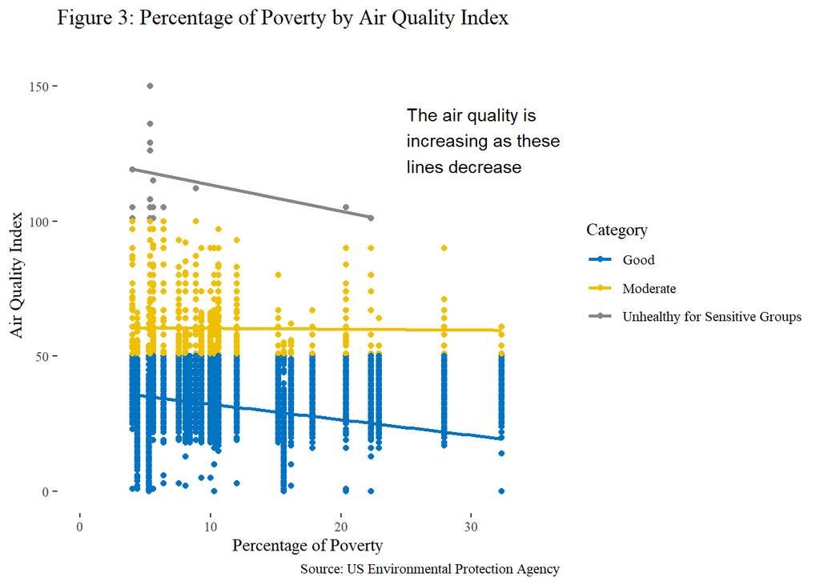

```r
df %>% ggplot(., aes(x=PercentPoverty, y=AQI)) +
  geom_point(aes(col=Category)) +
  geom_smooth(aes(col=Category), method="lm", se=F) +
  xlim(c(0, 35.0)) +
  ylim(c(0, 160)) +
  labs(y="Air Quality Index",
       x="Percentage of Poverty",
       title="Figure 3: Percentage of Poverty by Air Quality Index",
       caption = "Source: US Environmental Protection Agency") +
    annotate(geom="text",x=25,y=130,label="The air quality is \nincreasing as these\nlines decrease",hjust=0)+
#    annotate(geom="segment",x = 25,xend = 21,y=75,yend=100,size=1,color='blue')+
  scale_color_jco() +
  theme_tufte()
```